# Assignment 2

Author

Vicki Shen

```r
library(nycflights13)
library(dplyr)
library(ggplot2)
library(maps)
library(tidyr)
```

# Question 1

```r
top_10 <- flights %>%
  group_by(dest) %>%
  summarise(num_flights = n()) %>%
  arrange(desc(num_flights)) %>%
  slice_head(n = 10)

top_10
```

```
# A tibble: 10 × 2
   dest  num_flights
   <chr>       <int>
 1 ORD         17283
 2 ATL         17215
 3 LAX         16174
 4 BOS         15508
 5 MCO         14082
 6 CLT         14064
 7 SFO         13331
 8 FLL         12055
 9 MIA         11728
10 DCA          9705
```

The top 10 most popular destinations and the number of flights that went to each destination are:

1. **ORD** (Chicago): 17283
2. **ATL** (Atlanta): 17215
3. **LAX** (Los Angeles): 16174
4. **BOS** (Boston): 15508
5. **MCO** (Orlando): 14082
6. **CLT** (Charlotte): 14064
7. **SFO** (San Francisco): 13331
8. **FLL** (Fort Lauderdale): 12055
9. **MIA** (Miami): 11728
10. **DCA** (Arlington): 9705

# Question 2

```r
# Categorizing flight times
time_category <- function(time) {
  if (is.na(time)) return(NA)
  hour <- floor(time / 100)
  if (hour >= 0 & hour < 6) {
    return("early morning")
  } else if (hour >= 6 & hour < 12) {
    return("morning")
  } else if (hour >= 12 & hour < 18) {
    return("afternoon")
  } else {
    return("evening")
  }
}

# Creating categorical variables
flights_time <- flights %>%
  mutate(
    flight_dep = sapply(dep_time, time_category),
    flight_arr = sapply(arr_time, time_category)
  )
```

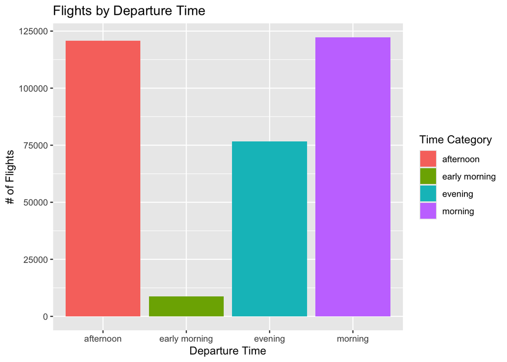

```r
# Departure Time Barplot
ggplot(flights_time %>% filter(!is.na(flight_dep))) +
  geom_bar(mapping = aes(x = flight_dep, fill = flight_dep)) +
  labs(title = "Flights by Departure Time",
       fill = "Time Category",
       x = "Departure Time",
       y = "# of Flights")
```

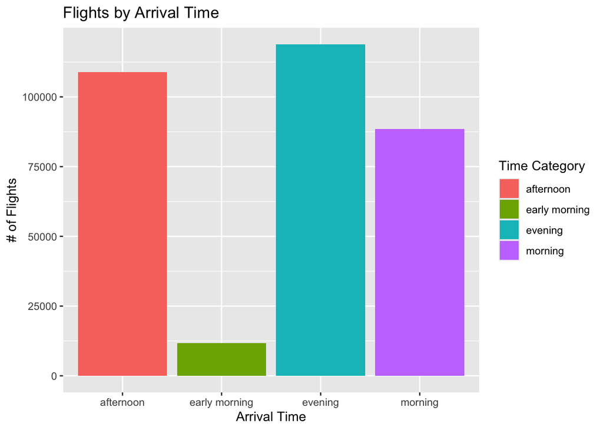

```r
# Arrival Time Barplot
ggplot(flights_time %>% filter(!is.na(flight_arr))) +
  geom_bar(mapping = aes(x = flight_arr, fill = flight_arr)) +
             labs(title = "Flights by Arrival Time",
                  fill = "Time Category",
                  x = "Arrival Time",
                  y = "# of Flights")
```

```r
# Calculating "red eye" flights
red_eye <- flights_time %>%
  filter(flight_dep %in% c("afternoon", "evening") &
           flight_arr %in% c("early morning", "morning"))

percent_red_eye <- nrow(red_eye) / nrow(flights_time) * 100

percent_red_eye
```

```
[1] 3.157291
```

Approximately 3.16% of flights were red eye flights, indicating that a relatively small but noticeable portion of flights depart later in the day and arrive early in the morning.

# Question 3

```r
# Check planes that flew for multiple airlines
multi_airline <- flights %>%
  filter(!is.na(tailnum)) %>%
  group_by(tailnum) %>%
  summarise(num_airlines = n_distinct(carrier),
            airlines = paste(unique(carrier), collapse = ", ")) %>%
  filter(num_airlines > 1)

multi_airline
```

```
# A tibble: 17 × 3
   tailnum num_airlines airlines
   <chr>          <int> <chr>
 1 N146PQ             2 9E, EV
 2 N153PQ             2 9E, EV
 3 N176PQ             2 9E, EV
 4 N181PQ             2 9E, EV
 5 N197PQ             2 9E, EV
 6 N200PQ             2 9E, EV
 7 N228PQ             2 9E, EV
 8 N232PQ             2 9E, EV
 9 N933AT             2 FL, DL
10 N935AT             2 FL, DL
11 N977AT             2 FL, DL
12 N978AT             2 FL, DL
13 N979AT             2 FL, DL
14 N981AT             2 FL, DL
15 N989AT             2 FL, DL
16 N990AT             2 FL, DL
17 N994AT             2 FL, DL
```

```r
# Count airlines
nrow(multi_airline)
```

```
[1] 17
```

**Answer**: There were 17 planes that flew for multiple airlines. These planes flew for two codeshare flights, aka two airlines using the same flight number: 9E (Endeavor Air) & EV (ExpressJet Airlines) and FL (AirTran Airways) & DL (Delta Air Lines).

# Question 4

**Answer**: In the diagram, origin under flights has a connection to faa under airports. The origin in weather should also have a connection to faa in airports. To demonstrate this relationship, there should be a line/arrow from origin in weather to the faa in airports. This link demonstrates that weather data are collected at specific airports, just as flight departures are from the same airports. The following codes below confirms this relationship is valid.

```r
# Check origin column in weather
weather %>%
  distinct(origin)
```

```
# A tibble: 3 × 1
  origin
  <chr>
1 EWR
2 JFK
3 LGA
```

Under the weather data set, the unique codes for origin are the three NYC airport codes: EWR, JFK, and LGA.

```r
# Check faa in airports
airports %>%
  select(faa, name) %>%
  filter(faa %in% c("EWR", "JFK", "LGA"))
```

```
# A tibble: 3 × 2
  faa   name
  <chr> <chr>
1 EWR   Newark Liberty Intl
2 JFK   John F Kennedy Intl
3 LGA   La Guardia
```

The unique codes from weather correspond to the same codes in faa in the airports data set.

```r
# Showing the connection
weather %>%
  left_join(airports, by = c("origin" = "faa"))
```

```
# A tibble: 26,115 × 22
   origin  year month   day  hour  temp  dewp humid wind_dir wind_speed
   <chr>  <int> <int> <int> <int> <dbl> <dbl> <dbl>    <dbl>      <dbl>
 1 EWR     2013     1     1     1  39.0  26.1  59.4      270      10.4
 2 EWR     2013     1     1     2  39.0  27.0  61.6      250       8.06
 3 EWR     2013     1     1     3  39.0  28.0  64.4      240      11.5
 4 EWR     2013     1     1     4  39.9  28.0  62.2      250      12.7
 5 EWR     2013     1     1     5  39.0  28.0  64.4      260      12.7
 6 EWR     2013     1     1     6  37.9  28.0  67.2      240      11.5
 7 EWR     2013     1     1     7  39.0  28.0  64.4      240      15.0
 8 EWR     2013     1     1     8  39.9  28.0  62.2      250      10.4
 9 EWR     2013     1     1     9  39.9  28.0  62.2      260      15.0
10 EWR     2013     1     1    10  41    28.0  59.6      260      13.8
# ℹ 26,105 more rows
# ℹ 12 more variables: wind_gust <dbl>, precip <dbl>, pressure <dbl>,
#   visib <dbl>, time_hour <dttm>, name <chr>, lat <dbl>, lon <dbl>, alt <dbl>,
#   tz <dbl>, dst <chr>, tzone <chr>
```

```r
# Check for unmatched codes
setdiff(weather$origin, airports$faa)
```

```
character(0)
```

The output from joining weather and airports comes out perfect, meaning that every record in weather corresponds to an airport in airports. This can be further supported by checking for unmatched codes which returned as character(0) so all origin values in weather exist in airports.

# Question 5

```r
# Pasting together the 5 variables
weather_key <- weather %>%
  mutate(key = paste(year, month, day, hour, origin, sep = "-"))

# Calculating duplicates
weather_dup <- weather_key %>%
  count(key) %>%
  filter(n > 1)

nrow(weather_dup)
```

```
[1] 3
```

```r
sum(weather_dup$n)
```

```
[1] 6
```

```r
# Looking at actual rows
weather_key %>%
  filter(key %in% weather_dup$key) %>%
  arrange(key)
```

```
# A tibble: 6 × 16
  origin  year month   day  hour  temp  dewp humid wind_dir wind_speed wind_gust
  <chr>  <int> <int> <int> <int> <dbl> <dbl> <dbl>    <dbl>      <dbl>     <dbl>
1 EWR     2013    11     3     1  52.0  39.0  61.2      310       6.90        NA
2 EWR     2013    11     3     1  50    39.0  65.8      290       5.75        NA
3 JFK     2013    11     3     1  54.0  37.9  54.5      320       9.21        NA
4 JFK     2013    11     3     1  52.0  37.9  58.6      310       6.90        NA
5 LGA     2013    11     3     1  55.0  39.0  54.7      330       9.21        NA
6 LGA     2013    11     3     1  54.0  39.9  58.9      310       8.06        NA
# ℹ 5 more variables: precip <dbl>, pressure <dbl>, visib <dbl>,
#   time_hour <dttm>, key <chr>
```

After taking a closer look at the 6 rows, there are two rows for the same year, month, day, hour, and origin, specifically the date 11/3/2013 at each airport. After a Google search, daylight savings ended on that date, so the clocks were set back one hour. Therefore, the 1:00am hour (1) happened twice, once in daylight savings time and once in standard time. Because two weather observations were recorded, when pasted together, the hours look the same. The variable time_hour can fix this glitch, which is why this tidy data set gives *almost* enough information.

```r
# Merging the flights and weather data sets
flights_weather <- flights %>%
  left_join(weather %>% select(-year, -month, -day, -hour),
            by = c("time_hour", "origin"))
```

# Question 6

```r
# Check size of the data
dim(flights_weather)
```

```
[1] 336776     28
```

```r
nrow(flights_weather)
```

```
[1] 336776
```

```r
ncol(flights_weather)
```

```
[1] 28
```

In this merged data set, there are 336776 rows and 28 columns.

```r
# Examine the variables and their types
str(flights_weather)
```

```
tibble [336,776 × 28] (S3: tbl_df/tbl/data.frame)
 $ year          : int [1:336776] 2013 2013 2013 2013 2013 2013 2013 2013 2013 2013 ...
 $ month         : int [1:336776] 1 1 1 1 1 1 1 1 1 1 ...
 $ day           : int [1:336776] 1 1 1 1 1 1 1 1 1 1 ...
 $ dep_time      : int [1:336776] 517 533 542 544 554 554 555 557 557 558 ...
 $ sched_dep_time: int [1:336776] 515 529 540 545 600 558 600 600 600 600 ...
 $ dep_delay     : num [1:336776] 2 4 2 -1 -6 -4 -5 -3 -3 -2 ...
 $ arr_time      : int [1:336776] 830 850 923 1004 812 740 913 709 838 753 ...
 $ sched_arr_time: int [1:336776] 819 830 850 1022 837 728 854 723 846 745 ...
 $ arr_delay     : num [1:336776] 11 20 33 -18 -25 12 19 -14 -8 8 ...
 $ carrier       : chr [1:336776] "UA" "UA" "AA" "B6" ...
 $ flight        : int [1:336776] 1545 1714 1141 725 461 1696 507 5708 79 301 ...
 $ tailnum       : chr [1:336776] "N14228" "N24211" "N619AA" "N804JB" ...
 $ origin        : chr [1:336776] "EWR" "LGA" "JFK" "JFK" ...
 $ dest          : chr [1:336776] "IAH" "IAH" "MIA" "BQN" ...
 $ air_time      : num [1:336776] 227 227 160 183 116 150 158 53 140 138 ...
 $ distance      : num [1:336776] 1400 1416 1089 1576 762 ...
 $ hour          : num [1:336776] 5 5 5 5 6 5 6 6 6 6 ...
 $ minute        : num [1:336776] 15 29 40 45 0 58 0 0 0 0 ...
 $ time_hour     : POSIXct[1:336776], format: "2013-01-01 05:00:00" "2013-01-01 05:00:00" ...
 $ temp          : num [1:336776] 39 39.9 39 39 39.9 ...
 $ dewp          : num [1:336776] 28 25 27 27 25 ...
 $ humid         : num [1:336776] 64.4 54.8 61.6 61.6 54.8 ...
 $ wind_dir      : num [1:336776] 260 250 260 260 260 260 240 260 260 260 ...
 $ wind_speed    : num [1:336776] 12.7 15 15 15 16.1 ...
 $ wind_gust     : num [1:336776] NA 21.9 NA NA 23 ...
 $ precip        : num [1:336776] 0 0 0 0 0 0 0 0 0 0 ...
 $ pressure      : num [1:336776] 1012 1011 1012 1012 1012 ...
 $ visib         : num [1:336776] 10 10 10 10 10 10 10 10 10 10 ...
```

```r
summary(flights_weather)
```

```
      year          month             day           dep_time    sched_dep_time
 Min.   :2013   Min.   : 1.000   Min.   : 1.00   Min.   :   1   Min.   : 106
 1st Qu.:2013   1st Qu.: 4.000   1st Qu.: 8.00   1st Qu.: 907   1st Qu.: 906
 Median :2013   Median : 7.000   Median :16.00   Median :1401   Median :1359
 Mean   :2013   Mean   : 6.549   Mean   :15.71   Mean   :1349   Mean   :1344
 3rd Qu.:2013   3rd Qu.:10.000   3rd Qu.:23.00   3rd Qu.:1744   3rd Qu.:1729
 Max.   :2013   Max.   :12.000   Max.   :31.00   Max.   :2400   Max.   :2359
                                                 NA's   :8255
   dep_delay          arr_time    sched_arr_time   arr_delay
 Min.   : -43.00   Min.   :   1   Min.   :   1   Min.   : -86.000
 1st Qu.:  -5.00   1st Qu.:1104   1st Qu.:1124   1st Qu.: -17.000
 Median :  -2.00   Median :1535   Median :1556   Median :  -5.000
 Mean   :  12.64   Mean   :1502   Mean   :1536   Mean   :   6.895
 3rd Qu.:  11.00   3rd Qu.:1940   3rd Qu.:1945   3rd Qu.:  14.000
 Max.   :1301.00   Max.   :2400   Max.   :2359   Max.   :1272.000
 NA's   :8255      NA's   :8713                  NA's   :9430
   carrier              flight       tailnum             origin
 Length:336776      Min.   :   1   Length:336776      Length:336776
 Class :character   1st Qu.: 553   Class :character   Class :character
 Mode  :character   Median :1496   Mode  :character   Mode  :character
                    Mean   :1972
                    3rd Qu.:3465
                    Max.   :8500

     dest              air_time        distance         hour
 Length:336776      Min.   : 20.0   Min.   :  17   Min.   : 1.00
 Class :character   1st Qu.: 82.0   1st Qu.: 502   1st Qu.: 9.00
 Mode  :character   Median :129.0   Median : 872   Median :13.00
                    Mean   :150.7   Mean   :1040   Mean   :13.18
                    3rd Qu.:192.0   3rd Qu.:1389   3rd Qu.:17.00
                    Max.   :695.0   Max.   :4983   Max.   :23.00
                    NA's   :9430
     minute        time_hour                        temp             dewp
 Min.   : 0.00   Min.   :2013-01-01 05:00:00   Min.   : 10.94   Min.   :-9.94
 1st Qu.: 8.00   1st Qu.:2013-04-04 13:00:00   1st Qu.: 42.08   1st Qu.:26.06
 Median :29.00   Median :2013-07-03 10:00:00   Median : 57.20   Median :42.80
 Mean   :26.23   Mean   :2013-07-03 05:22:54   Mean   : 57.00   Mean   :41.63
 3rd Qu.:44.00   3rd Qu.:2013-10-01 07:00:00   3rd Qu.: 71.96   3rd Qu.:57.92
 Max.   :59.00   Max.   :2013-12-31 23:00:00   Max.   :100.04   Max.   :78.08
                                               NA's   :1573     NA's   :1573
     humid           wind_dir       wind_speed       wind_gust
 Min.   : 12.74   Min.   :  0.0   Min.   : 0.000   Min.   :16.11
 1st Qu.: 43.99   1st Qu.:130.0   1st Qu.: 6.905   1st Qu.:20.71
 Median : 57.73   Median :220.0   Median :10.357   Median :24.17
 Mean   : 59.56   Mean   :201.5   Mean   :11.114   Mean   :25.25
 3rd Qu.: 75.33   3rd Qu.:290.0   3rd Qu.:14.960   3rd Qu.:28.77
 Max.   :100.00   Max.   :360.0   Max.   :42.579   Max.   :66.75
 NA's   :1573     NA's   :9796    NA's   :1634     NA's   :256391
     precip           pressure          visib
 Min.   :0.00000   Min.   : 983.8   Min.   : 0.000
 1st Qu.:0.00000   1st Qu.:1012.7   1st Qu.:10.000
 Median :0.00000   Median :1017.5   Median :10.000
 Mean   :0.00456   Mean   :1017.8   Mean   : 9.256
 3rd Qu.:0.00000   3rd Qu.:1022.8   3rd Qu.:10.000
 Max.   :1.21000   Max.   :1042.1   Max.   :10.000
 NA's   :1556      NA's   :38788    NA's   :1556
```

To answer the primary question, the key outcome is dep_delay since it tells us how late the flight left. An alternative outcome variable to look at is arr_delay, how late the flight arrived. Additionally, origin and carrier can be helpful when identifying if some airlines are more likely to have a delay.

Since the question is asking about weather phenomena, important variables to consider that can impact flight times are temp (especially extreme temperatures), dewp (humidity & fog), wind_speed, precip (rain/snow), and visib. Time-related variables such as month, day, and hour are important to provide context for delays such as seasonal weather patterns.

- Numeric variables are dep_delay, arr_delay, temp, dewp, humid, wind_speed, precip, visib
- Categorical variables are origin, carrier, month, day, and hour

```r
# Check proportion of NAs in important variables
flights_weather %>%
  summarise(across(c(dep_delay, arr_delay, temp, wind_speed, precip, visib),
                   ~ mean(is.na(.)),
                   .names = "missing_{col}"))
```

```
# A tibble: 1 × 6
  missing_dep_delay missing_arr_delay missing_temp missing_wind_speed
              <dbl>             <dbl>        <dbl>              <dbl>
1            0.0245            0.0280      0.00467            0.00485
# ℹ 2 more variables: missing_precip <dbl>, missing_visib <dbl>
```

```r
# Variables sorted from most to least missing
sort(colMeans(is.na(flights_weather)), decreasing = TRUE)
```

```
     wind_gust       pressure       wind_dir      arr_delay       air_time
   0.761310188    0.115174478    0.029087583    0.028000808    0.028000808
      arr_time       dep_time      dep_delay        tailnum     wind_speed
   0.025871796    0.024511842    0.024511842    0.007458964    0.004851890
          temp           dewp          humid         precip          visib
   0.004670760    0.004670760    0.004670760    0.004620282    0.004620282
          year          month            day sched_dep_time sched_arr_time
   0.000000000    0.000000000    0.000000000    0.000000000    0.000000000
       carrier         flight         origin           dest       distance
   0.000000000    0.000000000    0.000000000    0.000000000    0.000000000
          hour         minute      time_hour
   0.000000000    0.000000000    0.000000000
```

**Interpretation**: There are missing values (NAs) present in almost all of the important variables except for origin, carrier, month, day, and hour. Most of the variables do not have a huge amount of NAs except for wind_gust (76%), therefore, it is best to exclude wind_gust because there are too many missing values.

```r
# Look at the top and bottom of the data
head(flights_weather)
```

```
# A tibble: 6 × 28
   year month   day dep_time sched_dep_time dep_delay arr_time sched_arr_time
  <int> <int> <int>    <int>          <int>     <dbl>    <int>          <int>
1  2013     1     1      517            515         2      830            819
2  2013     1     1      533            529         4      850            830
3  2013     1     1      542            540         2      923            850
4  2013     1     1      544            545        -1     1004           1022
5  2013     1     1      554            600        -6      812            837
6  2013     1     1      554            558        -4      740            728
# ℹ 20 more variables: arr_delay <dbl>, carrier <chr>, flight <int>,
#   tailnum <chr>, origin <chr>, dest <chr>, air_time <dbl>, distance <dbl>,
#   hour <dbl>, minute <dbl>, time_hour <dttm>, temp <dbl>, dewp <dbl>,
#   humid <dbl>, wind_dir <dbl>, wind_speed <dbl>, wind_gust <dbl>,
#   precip <dbl>, pressure <dbl>, visib <dbl>
```

```r
tail(flights_weather)
```

```
# A tibble: 6 × 28
   year month   day dep_time sched_dep_time dep_delay arr_time sched_arr_time
  <int> <int> <int>    <int>          <int>     <dbl>    <int>          <int>
1  2013     9    30       NA           1842        NA       NA           2019
2  2013     9    30       NA           1455        NA       NA           1634
3  2013     9    30       NA           2200        NA       NA           2312
4  2013     9    30       NA           1210        NA       NA           1330
5  2013     9    30       NA           1159        NA       NA           1344
6  2013     9    30       NA            840        NA       NA           1020
# ℹ 20 more variables: arr_delay <dbl>, carrier <chr>, flight <int>,
#   tailnum <chr>, origin <chr>, dest <chr>, air_time <dbl>, distance <dbl>,
#   hour <dbl>, minute <dbl>, time_hour <dttm>, temp <dbl>, dewp <dbl>,
#   humid <dbl>, wind_dir <dbl>, wind_speed <dbl>, wind_gust <dbl>,
#   precip <dbl>, pressure <dbl>, visib <dbl>
```

**Interpretation**: In the tail of the merged data set, variables like dep_time, dep_delay, arr_time, and a few more are NA, meaning these flights never departed. This suggests that those flights were cancelled. If some flights were cancelled, there would be no actual departure time or arrival time, thus no delays and no airtime. The following code chunk shows the presence of missing departure times and the NAs.

```r
# Confirming this assumption
sum(is.na(flights$dep_time)) # number of missing dep times
```

```
[1] 8255
```

```r
flights %>%
  filter(is.na(dep_time)) %>%
  distinct(dep_time, arr_time, air_time, dep_delay, arr_delay)
```

```
# A tibble: 1 × 5
  dep_time arr_time air_time dep_delay arr_delay
     <int>    <int>    <dbl>     <dbl>     <dbl>
1       NA       NA       NA        NA        NA
```

Since the main question is asking about weather-related delays rather than weather-related cancellations, it is best to exclude cancelled flights because no delay time exists.

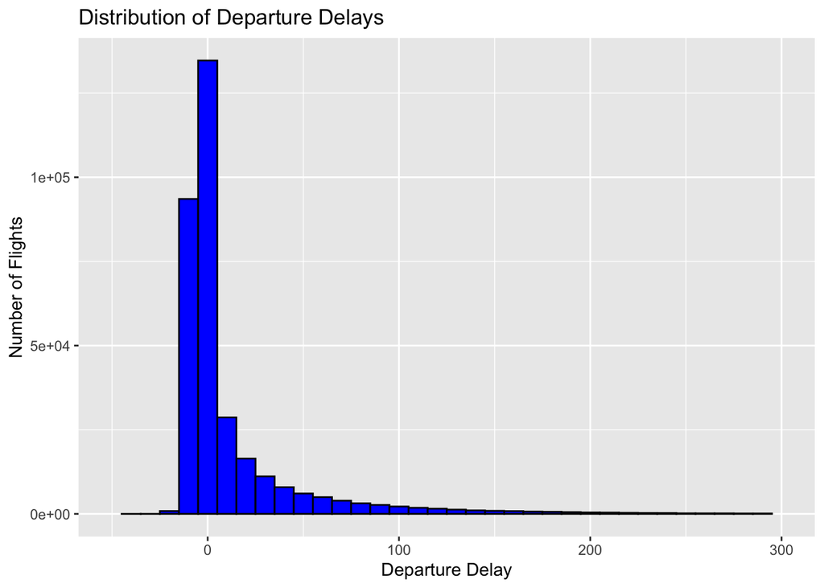

```r
# Visualize distribution of some key variables

# Departure delays
ggplot(flights_weather, aes(x = dep_delay)) +
  geom_histogram(binwidth = 10, fill = "blue", color = "black") +
  labs(title = "Distribution of Departure Delays",
       x = "Departure Delay",
       y = "Number of Flights") +
  xlim(-50, 300)
```

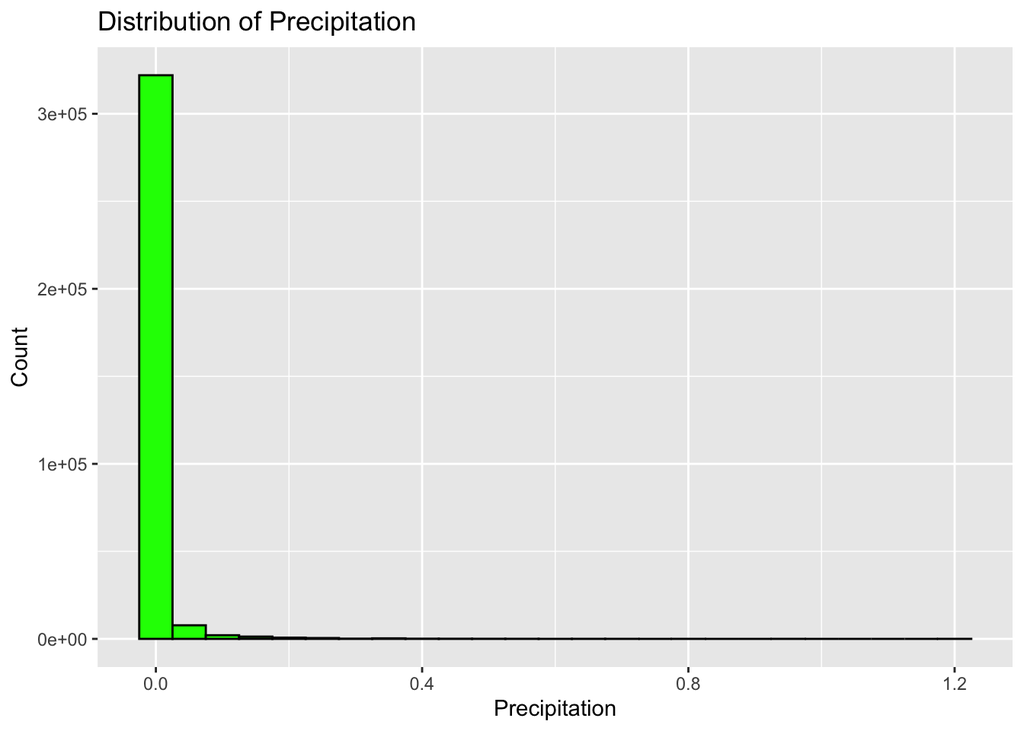

```r
# Precipitation
ggplot(flights_weather, aes(x = precip)) +
  geom_histogram(binwidth = 0.05, fill = "green", color = "black") +
  labs(title = "Distribution of Precipitation",
       x = "Precipitation",
       y = "Count")
```

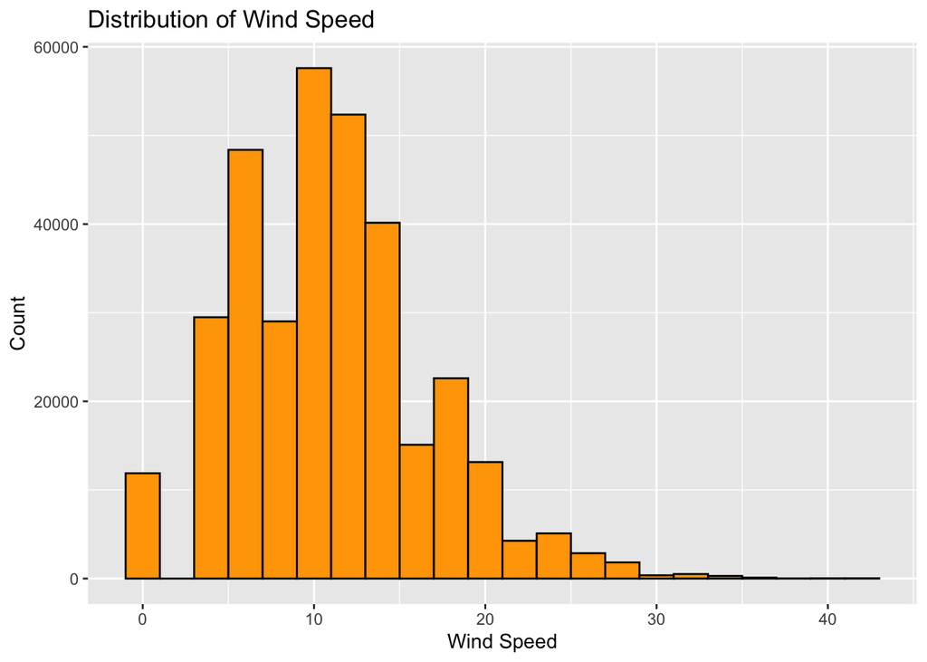

```r
# Wind Speed
ggplot(flights_weather, aes(x = wind_speed)) +
  geom_histogram(binwidth = 2, fill = "orange", color = "black") +
  labs(title = "Distribution of Wind Speed",
       x = "Wind Speed",
       y = "Count")
```

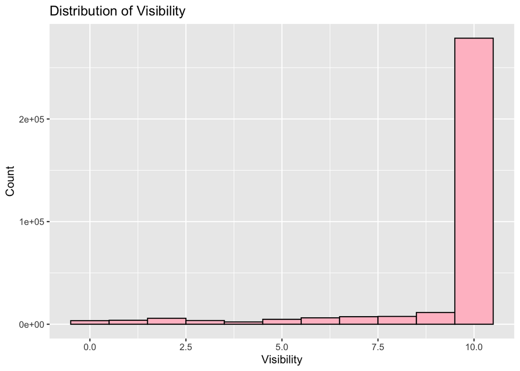

```r
# Visibility
ggplot(flights_weather, aes(x = visib)) +
  geom_histogram(binwidth = 1, fill = "pink", color = "black") +
  labs(title = "Distribution of Visibility",
       x = "Visibility",
       y = "Count")
```

**Interpretation**: By looking at the distribution of departure delays, most of the departure times were only delayed by a few minutes, given the strong right-skew of the histogram. However, there is quite a long, extended tail towards longer delays, indicating that some flights did experience significant delays.

The distribution of precipitation is heavily right-skewed, with most values condensed towards 0. There are only a few observations showing some precipitation. Therefore, most flights departed in dry conditions, but the rare cases of precipitation may influence delay times, making it an important variable to look at.

The wind speed distribution has a slight skewed distribution centered at 10 mph, with moments of higher speeds. After a Google search, departing flights are impacted by wind speeds exceeding 35-40 mph, which only happened a few times, however, the presence of wind can still impact takeoff/landing.

Visibility, on the other hand, has a big left skew with values condensed towards 10 miles, but there are observations at lower visibility. Thus, while low visibility was not common, it can still have an impact on flight delays.

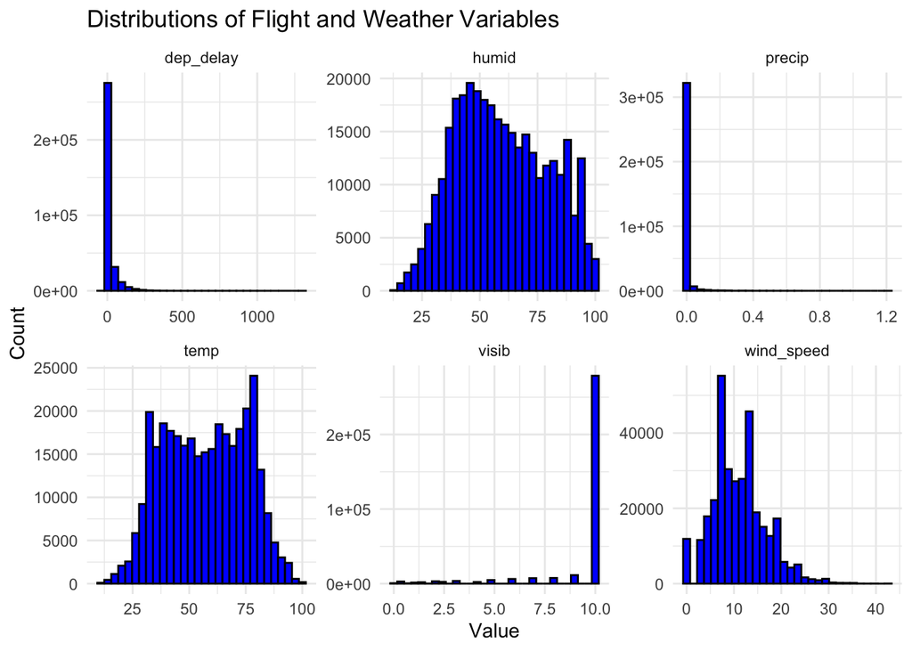

```r
# Distribution of some numeric variables
flights_weather %>%
  select(dep_delay, temp, humid, wind_speed, precip, visib) %>%
  pivot_longer(cols = everything(), names_to = "variable", values_to = "value") %>%
  ggplot(aes(x = value)) +
  geom_histogram(fill = "blue", color = "black", bins = 30) +
  facet_wrap(~ variable, scales = "free", ncol = 3) +
  labs(title = "Distributions of Flight and Weather Variables",
       x = "Value", y = "Count") +
  theme_minimal()
```

**Overall**, across most of the weather-related variables, there are instances of extreme conditions (high wind, precipitation, poor visibility, high/low humidity, high/low temps) that do occur, but these rare events may have disproportionately large effects on flight delays.

# Question 7

```r
# Calculate average departure delay for each day
avg_day <- flights_weather %>%
  group_by(month, day) %>%
  summarise(avg_dep_delay = mean(dep_delay, na.rm = TRUE)) %>%
  arrange(desc(avg_dep_delay))
head(avg_day, 1)
```

```
# A tibble: 1 × 3
# Groups:   month [1]
  month   day avg_dep_delay
  <int> <int>         <dbl>
1     3     8          83.5
```

**Answer**: The day that had the worst average departure delay in 2013 was on 03/08 with an average of 83.5 minutes.

```r
# Calculate average by day and origin
avg_day_origin <- flights_weather %>%
  group_by(origin, month, day) %>%
  summarise(avg_dep_delay = mean(dep_delay, na.rm = TRUE)) %>%
  arrange(desc(avg_dep_delay))
head(avg_day_origin, 1)
```

```
# A tibble: 1 × 4
# Groups:   origin, month [1]
  origin month   day avg_dep_delay
  <chr>  <int> <int>         <dbl>
1 LGA        3     8          106.
```

**Answer**: The airport that had the worst single day for delays in 2013 was LGA on 03/08 with an average delay time of 105.7 minutes.

```r
# Calculate average by hour and origin
avg_hour_origin <- flights_weather %>%
  group_by(origin, month, day, hour) %>%
  summarise(avg_dep_delay = mean(dep_delay, na.rm = TRUE)) %>%
  arrange(desc(avg_dep_delay))
head(avg_hour_origin, 1)
```

```
# A tibble: 1 × 5
# Groups:   origin, month, day [1]
  origin month   day  hour avg_dep_delay
  <chr>  <int> <int> <dbl>         <dbl>
1 LGA        7    28    21          280.
```

**Answer**: The airport that had the worst single hour for delays in 2013 was LGA at hour 21 (9:00pm) on 07/28 with an average delay of 279.7 minutes.

# Question 8

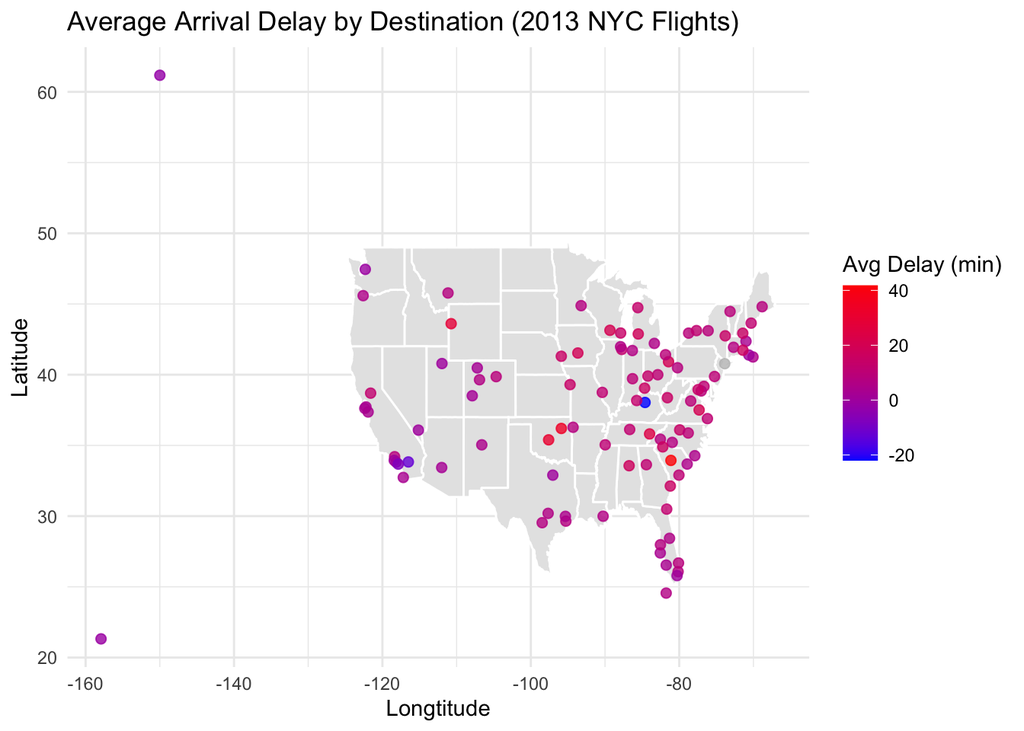

```r
# Compute average delay by destination & add to airports data frame
avg_delay_dest <- flights_weather %>%
  group_by(dest) %>%
  summarise(avg_arr_delay = mean(arr_delay, na.rm = TRUE)) %>%
  left_join(airports, by = c("dest" = "faa"))

# Make map of spatial distribution of delays
us_map <- map_data("state")

ggplot() +
  geom_polygon(data = us_map, aes(x = long, y = lat, group = group),
               fill = "gray90", color = "white") +
  geom_point(data = avg_delay_dest, aes(x = lon, y = lat, color = avg_arr_delay),
             size = 2, alpha = 0.8) +
  scale_color_gradient(low = "blue", high = "red", na.value = "gray") +
  labs(title = "Average Arrival Delay by Destination (2013 NYC Flights)",
       x = "Longtitude", y = "Latitude",
       color = "Avg Delay (min)") +
  theme_minimal()
```

**Interpretation**: Overall, most of the flight delays occur in the northeastern and mid-western regions. The longest arrival delays (shown in red) are evident in Oklahoma, South Carolina, and Wyoming.

# Question 9

To answer the primary question, departure delay (dep_delay) will be the main outcome. From the weather data set, typical variables that can impact delays are temperature, dew point, humidity, wind direction, wind speed, precipitation, visibility, and pressure. From Question 6, wind gust had more than 50% NAs, so this variable will not be included in the analysis.

First, let’s see the correlations between the weather variables and departure delay.

```r
weather_var <- flights_weather %>%
  select(dep_delay, temp, dewp, humid, wind_speed, wind_dir, precip, visib, pressure)

cor_matrix <- cor(weather_var, use = "complete.obs")
cor_matrix["dep_delay", ]
```

```
  dep_delay        temp        dewp       humid  wind_speed    wind_dir
 1.00000000  0.07008893  0.09381900  0.08079981  0.03428811 -0.01319015
     precip       visib    pressure
 0.05138536 -0.06243153 -0.11422344
```

All of the values calculated are very weak relationships and not much can be concluded based off of this information alone.

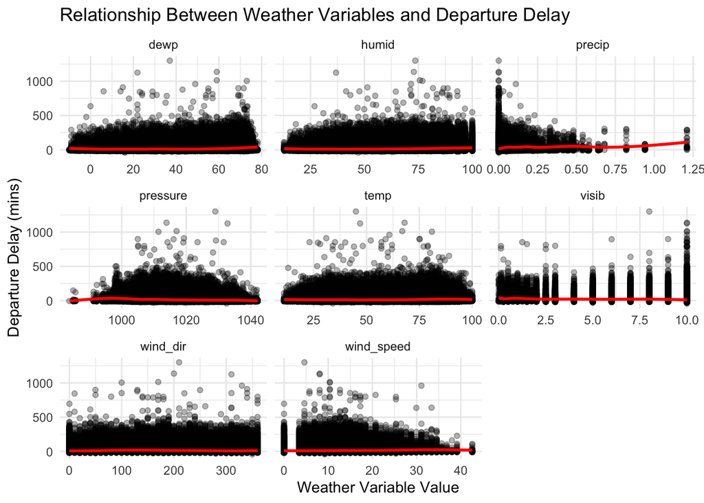

```r
# Visualization of relationship between weather and departure delay
weather_var <- c("temp", "dewp", "humid", "wind_speed", "wind_dir", "precip", "pressure", "visib")

flights_weather %>%
  select(dep_delay, all_of(weather_var)) %>%
  pivot_longer(cols = all_of(weather_var),
               names_to = "weather_variable",
               values_to = "value") %>%
  filter(!is.na(dep_delay)) %>%
  ggplot(aes(x = value, y = dep_delay)) +
  geom_point(alpha = 0.3) +
  geom_smooth(color = "red", se = FALSE) +
  facet_wrap(~ weather_variable, scales = "free_x") +
  theme_minimal() +
  labs(title = "Relationship Between Weather Variables and Departure Delay",
       x = "Weather Variable Value",
       y = "Departure Delay (mins)")
```

**Interpretation**: Overall, not much can be inferred based on the scatter plots either, with the exception of precipitation. The regression line for precipitation is the most noticeable.

Since simple linear correlation and plots alone are not helpful, this suggests to look at non-linear and threshold effects of weather on delays. For example, flight delays are more likely to occur if wind speeds exceeds a specific threshold.

Additionally, since there are a lot of weather variables, we need to figure out which variables will be the most important indicator.

```r
# Filter NAs and remove wind_gust to fit in regression model
model_data <- flights_weather %>%
  filter(!is.na(dep_delay), !is.na(temp), !is.na(visib), !is.na(precip), !is.na(pressure), !is.na(wind_speed)) %>%
  select(dep_delay, temp, dewp, humid, wind_speed, precip, pressure, visib)

lm_model <- lm(dep_delay ~ temp + dewp + humid + wind_speed + precip + pressure + visib, data = model_data)

summary(lm_model)
```

```
Call:
lm(formula = dep_delay ~ temp + dewp + humid + wind_speed + precip +
    pressure + visib, data = model_data)

Residuals:
    Min      1Q  Median      3Q     Max
 -67.42  -16.79  -11.18   -0.67 1294.40

Coefficients:
             Estimate Std. Error t value Pr(>|t|)
(Intercept) 379.58221   10.87605  34.901  < 2e-16 ***
temp          0.45156    0.04202  10.746  < 2e-16 ***
dewp         -0.36557    0.04529  -8.072 6.95e-16 ***
humid         0.31086    0.02317  13.419  < 2e-16 ***
wind_speed    0.30425    0.01389  21.905  < 2e-16 ***
precip       73.00641    5.87531  12.426  < 2e-16 ***
pressure     -0.38939    0.01024 -38.028  < 2e-16 ***
visib        -0.41722    0.06194  -6.736 1.63e-11 ***
---
Signif. codes:  0 '***' 0.001 '**' 0.01 '*' 0.05 '.' 0.1 ' ' 1

Residual standard error: 37.28 on 292130 degrees of freedom
Multiple R-squared:  0.02203,   Adjusted R-squared:  0.02201
F-statistic:   940 on 7 and 292130 DF,  p-value: < 2.2e-16
```

**Note**: Humidity already incorporates dew point in its calculation and they are also strongly related, so we don’t need to interpret both to make it easier to interpret.

```r
# Convert continuous weather variables into categories and visual plot

# Precipitation
precip_summary <- flights_weather %>%
  mutate(
    precip_cat = case_when(
      precip == 0 ~ "None",
      precip > 0 & precip <= 0.05 ~ "Light",
      precip > 0.05 & precip <= 0.20 ~ "Moderate",
      precip > 0.20 & precip <= 0.50 ~ "Heavy",
      precip > 0.50 ~ "Extreme"
    )
  ) %>%
  group_by(precip_cat) %>%
  summarise(
    n_flights = n(),
    avg_delay = mean(dep_delay, na.rm = TRUE),
    pct_flights = n_flights / nrow(flights_weather) * 100,
    .groups = "drop"
  )

print(precip_summary)
```

```
# A tibble: 6 × 4
  precip_cat n_flights avg_delay pct_flights
  <chr>          <int>     <dbl>       <dbl>
1 Extreme          175      48.8      0.0520
2 Heavy           1535      40.4      0.456
3 Light          15565      27.9      4.62
4 Moderate        5727      36.5      1.70
5 None          312218      11.4     92.7
6 <NA>            1556      13.4      0.462
```

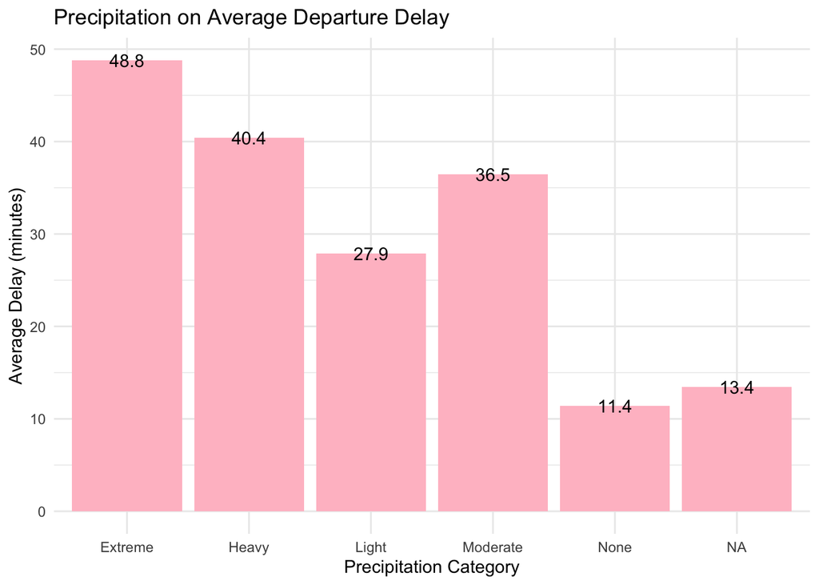

```r
precip_plot <- ggplot(precip_summary, aes(x = precip_cat, y = avg_delay)) +
  geom_bar(stat = "identity", fill = "pink") +
  geom_text(aes(label = round(avg_delay, 1))) +
  labs(
    title = "Precipitation on Average Departure Delay",
    x = "Precipitation Category",
    y = "Average Delay (minutes)"
  ) +
  theme_minimal()

print(precip_plot)
```

```r
# Visibility
visib_summary <- flights_weather %>%
  mutate(
    visib_cat = case_when(
      visib >= 10 ~ "Clear (>= 10 mi)",
      visib >= 5 ~ "Reduced (5-10 mi)",
      visib <= 1 ~ "Poor (1-5 mi)",
      TRUE ~ "Very Poor (< 1 mi)"
    )
  ) %>%
  group_by(visib_cat) %>%
  summarise(
    n_flights = n(),
    avg_delay = mean(dep_delay, na.rm = TRUE),
    pct_flights = n_flights / nrow(flights_weather) * 100,
    .groups = "drop"
  )

print(visib_summary)
```

```
# A tibble: 4 × 4
  visib_cat          n_flights avg_delay pct_flights
  <chr>                  <int>     <dbl>       <dbl>
1 Clear (>= 10 mi)      278739      11.0       82.8
2 Poor (1-5 mi)           5449      30.4        1.62
3 Reduced (5-10 mi)      37466      19.6       11.1
4 Very Poor (< 1 mi)     15122      21.5        4.49
```

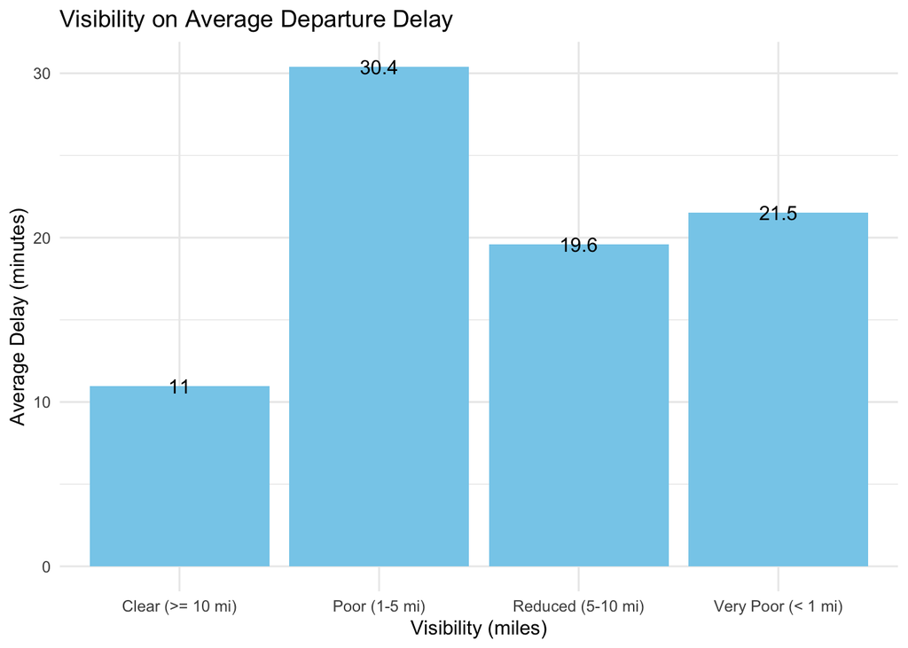

```r
visib_plot <- ggplot(visib_summary, aes(x = visib_cat, y = avg_delay)) +
  geom_bar(stat = "identity", fill = "skyblue") +
  geom_text(aes(label = round(avg_delay, 1))) +
  labs(
    title = "Visibility on Average Departure Delay",
    x = "Visibility (miles)",
    y = "Average Delay (minutes)"
  ) +
  theme_minimal()

print(visib_plot)
```

```r
# Wind Speed
wind_summary <- flights_weather %>%
  mutate(
    wind_cat = case_when(
      wind_speed < 10 ~ "Calm (< 10 mph)",
      wind_speed < 20 ~ "Moderate (10-20 mph)",
      wind_speed < 30 ~ "Strong (20-30 mph)",
      TRUE ~ "Severe (>= 30 mph)"
    )
  ) %>%
  group_by(wind_cat) %>%
  summarise(
    n_flights = n(),
    avg_delay = mean(dep_delay, na.rm = TRUE),
    pct_flights = n_flights / nrow(flights_weather) * 100,
    .groups = "drop"
  )

print(wind_summary)
```

```
# A tibble: 4 × 4
  wind_cat             n_flights avg_delay pct_flights
  <chr>                    <int>     <dbl>       <dbl>
1 Calm (< 10 mph)         149178      11.0      44.3
2 Moderate (10-20 mph)    164770      13.6      48.9
3 Severe (>= 30 mph)        2627      18.4       0.780
4 Strong (20-30 mph)       20201      16.4       6.00
```

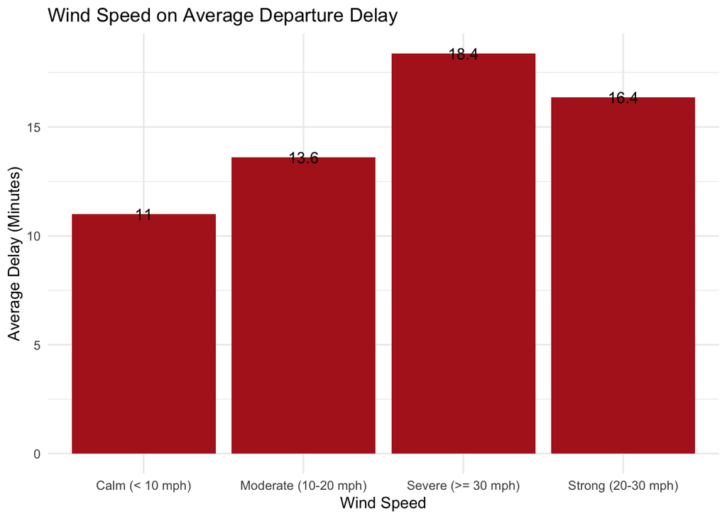

```r
wind_plot <- ggplot(wind_summary, aes(x = wind_cat, y = avg_delay)) +
  geom_bar(stat = "identity", fill = "firebrick") +
  geom_text(aes(label = round(avg_delay, 1))) +
  labs(
    title = "Wind Speed on Average Departure Delay",
    x = "Wind Speed",
    y = "Average Delay (Minutes)"
  ) +
  theme_minimal()

print(wind_plot)
```

```r
# Temperature
temp_summary <- flights_weather %>%
  mutate(
    temp_cat = case_when(
      temp < 40 ~ "Cold (< 40F)",
      temp < 75 ~ "Mild (40-75F)",
      temp < 90 ~ "Warm (75-90F)",
      TRUE ~ "Hot (>= 90F)"
    )
  ) %>%
  group_by(temp_cat) %>%
  summarise(
    n_flights = n(),
    avg_delay = mean(dep_delay, na.rm = TRUE),
    pct_flights = n_flights / nrow(flights_weather) * 100,
    .groups = "drop"
  )

print(temp_summary)
```

```
# A tibble: 4 × 4
  temp_cat      n_flights avg_delay pct_flights
  <chr>             <int>     <dbl>       <dbl>
1 Cold (< 40F)      75682      11.3       22.5
2 Hot (>= 90F)       6915      17.6        2.05
3 Mild (40-75F)    189148      10.8       56.2
4 Warm (75-90F)     65031      19.2       19.3
```

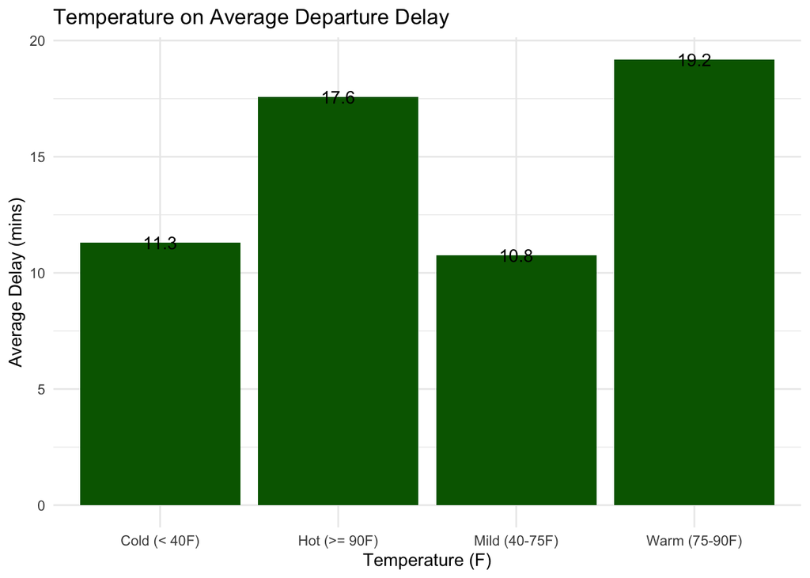

```r
temp_plot <- ggplot(temp_summary, aes(x = temp_cat, y = avg_delay)) +
  geom_bar(stat = "identity", fill = "darkgreen") +
  geom_text(aes(label = round(avg_delay, 1))) +
  labs(
    title = "Temperature on Average Departure Delay",
    x = "Temperature (F)",
    y = "Average Delay (mins)"
  ) +
  theme_minimal()

print(temp_plot)
```

```r
# Humidity
humid_summary <- flights_weather %>%
  mutate(
    humid_cat = case_when(
      humid < 40 ~ "Low (< 40%)",
      humid <= 60 ~ "Moderate (50-60%)",
      TRUE ~ "High (> 60%)"
    )
  ) %>%
  group_by(humid_cat) %>%
  summarise(
    n_flights = n(),
    avg_delay = mean(dep_delay, na.rm = TRUE),
    pct_flights = n_flights / nrow(flights_weather) * 100,
    .groups = "drop"
  )

print(humid_summary)
```

```
# A tibble: 3 × 4
  humid_cat         n_flights avg_delay pct_flights
  <chr>                 <int>     <dbl>       <dbl>
1 High (> 60%)         156515     17.0         46.5
2 Low (< 40%)           59894      8.89        17.8
3 Moderate (50-60%)    120367      9.03        35.7
```

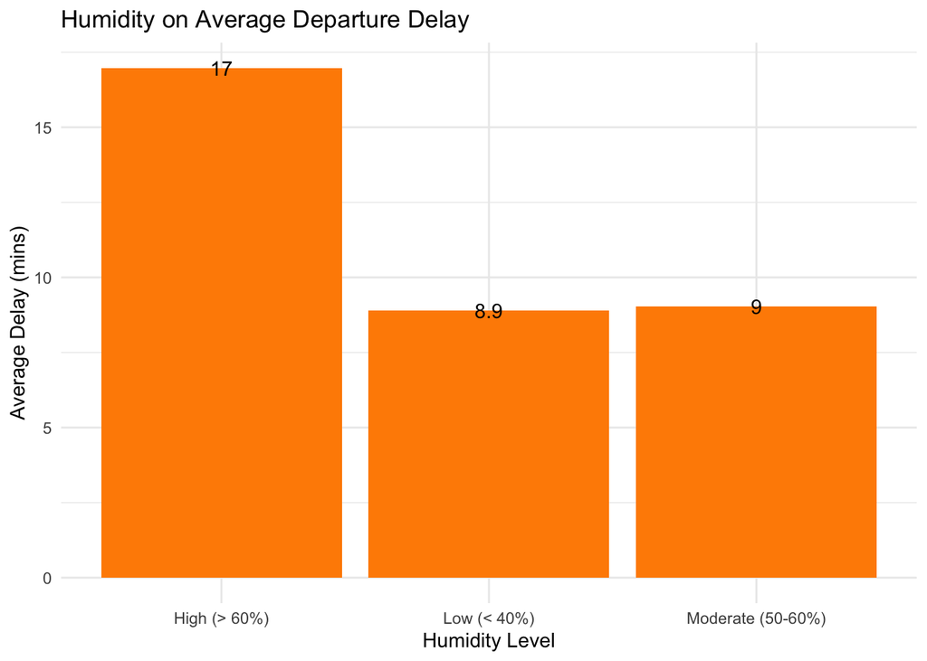

```r
humid_plot <- ggplot(humid_summary, aes(x = humid_cat, y = avg_delay)) +
  geom_bar(stat = "identity", fill = "darkorange") +
  geom_text(aes(label = round(avg_delay, 1))) +
  labs(
    title = "Humidity on Average Departure Delay",
    x = "Humidity Level",
    y = "Average Delay (mins)"
  ) +
  theme_minimal()

print(humid_plot)
```

```r
# Pressure
pressure_summary <- flights_weather %>%
  mutate(
    pressure_cat = case_when(
      pressure < 1010 ~ "Low Pressure (< 1010 mb)",
      pressure <= 1020 ~ "Standard Pressure (1010-1020 mb)",
      TRUE ~ "High Pressure (> 1020 mb)"
    )
  ) %>%
  group_by(pressure_cat) %>%
  summarise(
    n_flights = n(),
    avg_delay = mean(dep_delay, na.rm = TRUE),
    pct_flights = n_flights / nrow(flights_weather) * 100,
    .groups = "drop"
  )

print(pressure_summary)
```

```
# A tibble: 3 × 4
  pressure_cat                     n_flights avg_delay pct_flights
  <chr>                                <int>     <dbl>       <dbl>
1 High Pressure (> 1020 mb)           150270      11.4        44.6
2 Low Pressure (< 1010 mb)             42035      19.1        12.5
3 Standard Pressure (1010-1020 mb)    144471      12.1        42.9
```

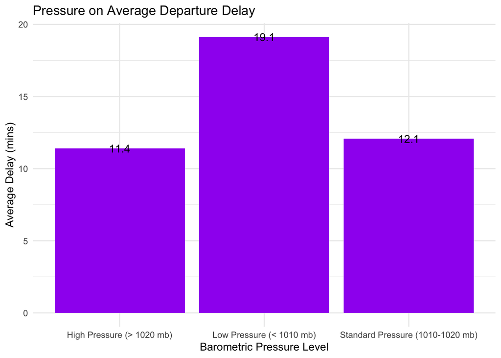

```r
pressure_plot <- ggplot(pressure_summary, aes(x = pressure_cat, y = avg_delay)) +
  geom_bar(stat = "identity", fill = "purple") +
  geom_text(aes(label = round(avg_delay, 1))) +
  labs(
    title = "Pressure on Average Departure Delay",
    x = "Barometric Pressure Level",
    y = "Average Delay (mins)"
  ) +
  theme_minimal()

print(pressure_plot)
```

**Interpretation**: The initial correlations were misleading because they only measured linear relationships, thus by breaking down relevant variables and calculating th average delay within each category, there is a threshold effect that causes delays. Also, categorizing numerical values into essentially low, medium, and high groups, helps in figuring out what degree of each variable is responsible for departure delays. Estimating the value ranges for each variable were decided based on online research.

In conclusion, the weather phenomena that has the most impact on flight delays in 2013 for NYC airports are extreme precipitation, low visibility, severe wind speeds, and warm temperatures with precipitation having the longest impact. Humidity and pressure serves as a signal for the top factors. For example, low pressure indicates severe weather like high winds and high humidity is a precursor for low visibility (fog formation).